# Exploratory Analysis

Jacob Ye, Matt Taniguchi, Ryan Oh, Javid Nuriyev

11/19/2021

# Introduction

In this analysis, we are looking at a life expectancy dataset obtained from Kaggle. This data is originally sourced from the WHO, and contains information regarding life expectancy and other factors which affect it (education, alcohol consumption, rates of diseases, etc.).

# Summary

The set contains data from **193 different countries** in the **years 2000 to 2015**. There are **22 features** in this set with **2938 observations**. There are a total of **161 developing** countries and **32 developed** countries. The ratio between the developing to developed countries and the ratio of developing to developed observations matches closely. Both developing and developed countries share a **maximum life expectancy of 89**, while the developing countries’ minimum is almost half **(36.3)** of the developed countries minimum **(69.9)**. This trend of developing countries having the lower end of life expectancies was expected. Through further analysis, we will be able to understand which factors in these developing countries have a negative effect on life expectancy.

# Aggregate Table

| Status | avg_expectancy | avg_population | avg_gdp |
| --- | --- | --- | --- |
| Developed | 79.2 | 6830053 | 22053 |
| Developing | 67.1 | 14071077 | 4287 |

The most meaningful way to group each country was by whether it was developing or developed, which is why we only have two rows in this table. The averages are simply the means of the corresponding values (expectancy, population, gdp). Despite the small number of rows in this table, we can still obtain a lot of information about the average differences between developing and developed countries. Developing countries have a **noticeably lower life expectancy** than developed countries, with much **higher populations** and **significantly less GDP** than developed countries. It is astonishing to see how larger developing countries’ populations are, almost **twice that of developed countries**. Even more astonishing but somewhat unsurprising is how developed countries’ average GDP almost **quintuples that of developing countries**.

# Chart 1

## Life Expectancy over Time

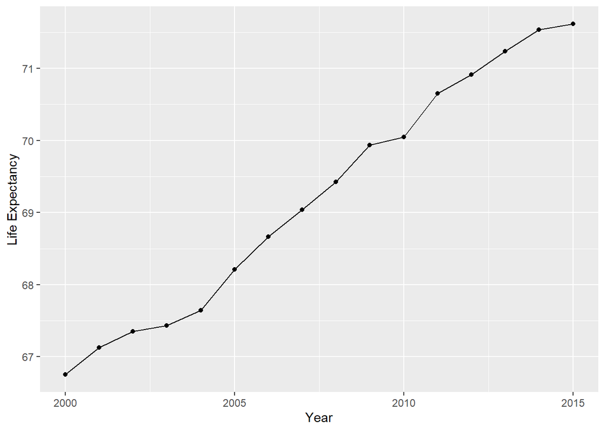

We included this chart to show how life expectancy has changed over the years. We think that it’s important to see the general trend and see if it aligns of what we think how life expectancy should change, and We think that it does corroborate with our beliefs that as time passes on, our health technology gets better. Though it is important to mention that despite knowing that it improves over time, it doesn’t show what is explicitly causing it to increase.

# Chart 2

## Average Infant Death Rate by Year

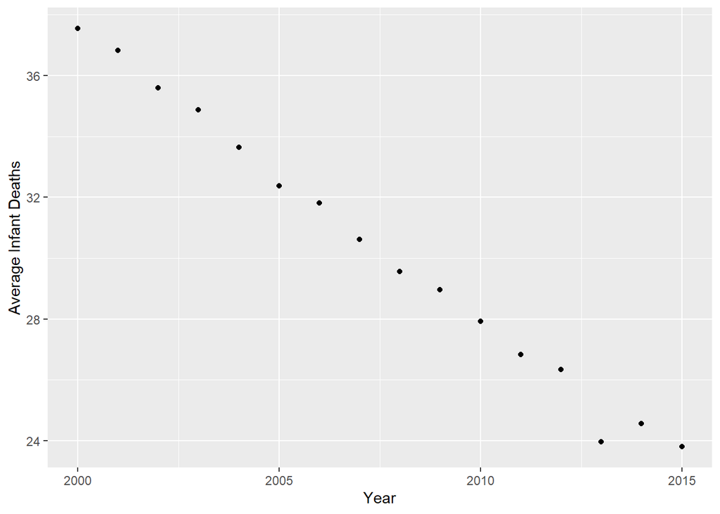

A good look at the infant deaths by the year can help us draw connections to overall societal conditions The infant death rate can reveal whether or not our world as a whole is healthy. We can then use this to connect years where morality rates maybe to high to reasoning that the world was affected by a variable which impacted global health.

From the chart, we can deduce that the trend of infant death rates goes down as the years increase. This shows us that the global health is improving, but this data set does not include COVID affected years, which will be interesting to see going forward as there was a global health crisis.

# Chart 3

## Average Life Expectancy over Country by Status

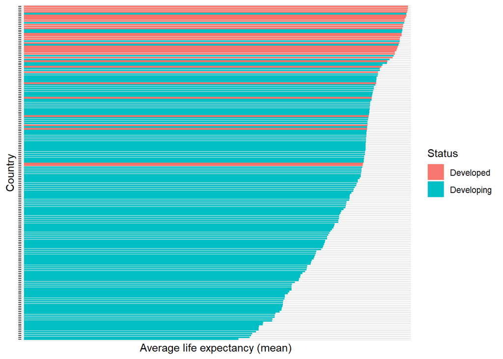

This plot shows average life expectancy of each country dividing them by developed and developing countries. We can observe that developing countries have lower life expectancy than developed countries. It gives us an understanding that life expectancy is depend on country’s status. After this point, we can further explore what variables affect country’s status, and find a relationship between those variables and life expectancy.